[figure not shown]

### Prof. José Manuel Magallanes, PhD

- Associate Professor, Departamento de Ciencias Sociales, Pontificia Universidad Católica del Perú, jmagallanes@pucp.edu.pe
- Visiting Associate Professor, Evans School of Public Policy and Governance / Senior Data Science Fellow, eScience Institute, University of Washington, magajm@uw.edu

# Session 2: Introduction to R.

Session contents:

- Opening Data Files
- Operations on Data frames
- Basic plotting
- Basic Clustering
- Basic Regression

# Opening data files

There are different ways to open files. Each requires a different function. In our case, we will open an **rds** file like this:

```r
worldData=readRDS('allmerged.rds')
```

If you have a format different than **rds**, like Excel or Stata, you may try:

```r
library(rio)
#worldData=import('somename.extension')
```

You have the data now. You can see WHAT you have like this:

```r
str(worldData)
```

```
## 'data.frame':    142 obs. of  13 variables:
##  $ Country                        : chr  "Norway" "Sweden" "New Zealand" "Canada" ...
##  $ Regime_type                    : Ord.factor w/ 4 levels "Authoritarian"<..: 4 4 4 4 4 4 4 4 4 4 ...
##  $ DemoIndex                      : num  9.81 9.26 9.25 9.24 9.2 9.15 9.05 8.96 8.96 8.83 ...
##  $ Electoral_process_and_pluralism: num  10 9.58 10 9.58 10 10 10 10 9.58 9.58 ...
##  $ Functioning_of_government      : num  9.64 9.29 8.93 8.93 8.93 8.93 7.86 8.57 9.29 8.57 ...
##  $ Political_participation        : num  10 8.33 8.89 8.89 8.89 8.33 8.33 7.78 8.33 7.78 ...
##  $ Political_culture              : num  10 10 8.75 9.38 8.75 9.38 9.38 8.75 8.75 9.38 ...
##  $ Civil_liberties                : num  9.41 9.12 9.71 9.41 9.41 9.12 9.71 9.71 8.82 8.82 ...
##  $ DefenseIndex                   : num  2 1.2 1.5 1.39 2.2 1.41 0.27 2.1 1.45 0.8 ...
##  $ FIPS                           : chr  "NO" "SW" "NZ" "CA" ...
##  $ ISO2                           : chr  "NO" "SE" "NZ" "CA" ...
##  $ ISO3                           : chr  "NOR" "SWE" "NZL" "CAN" ...
##  $ HDIndex                        : num  0.957 0.945 0.931 0.929 0.938 0.94 0.955 0.944 0.944 0.955 ...
```

This is the data frame you created in Python in the previous session. And you may have noticed the variable *Regime_type* has kept the **ordinal** conversion we did. If had saved that file in a different format, you would have lost that change .

However, something of Python remains:

```r
head(worldData)
```

```
##       Country    Regime_type DemoIndex Electoral_process_and_pluralism
## 0      Norway Full democracy      9.81                           10.00
## 1      Sweden Full democracy      9.26                            9.58
## 2 New Zealand Full democracy      9.25                           10.00
## 3      Canada Full democracy      9.24                            9.58
## 4     Finland Full democracy      9.20                           10.00
## 5     Denmark Full democracy      9.15                           10.00
##   Functioning_of_government Political_participation Political_culture
## 0                      9.64                   10.00             10.00
## 1                      9.29                    8.33             10.00
## 2                      8.93                    8.89              8.75
## 3                      8.93                    8.89              9.38
## 4                      8.93                    8.89              8.75
## 5                      8.93                    8.33              9.38
##   Civil_liberties DefenseIndex FIPS ISO2 ISO3 HDIndex
## 0            9.41         2.00   NO   NO  NOR   0.957
## 1            9.12         1.20   SW   SE  SWE   0.945
## 2            9.71         1.50   NZ   NZ  NZL   0.931
## 3            9.41         1.39   CA   CA  CAN   0.929
## 4            9.41         2.20   FI   FI  FIN   0.938
## 5            9.12         1.41   DA   DK  DNK   0.940
```

The index starts with ‘0’, so we only reset the index for R:

```r
row.names(worldData)=NULL   # reset indexes from Python.
```

Let’s work with this data frame.

home

## Operations on data frames:

Let’s see some operation on data frames:

### QUERYING:

- What is the country with highest HDIndex?

```r
# you could get more than one
worldData[worldData$HDIndex==max(worldData$HDIndex,na.rm=TRUE),]
```

```
##   Country    Regime_type DemoIndex Electoral_process_and_pluralism
## 1  Norway Full democracy      9.81                              10
##   Functioning_of_government Political_participation Political_culture
## 1                      9.64                      10                10
##   Civil_liberties DefenseIndex FIPS ISO2 ISO3 HDIndex
## 1            9.41            2   NO   NO  NOR   0.957
```

```r
#or
worldData[which(worldData$HDIndex==max(worldData$HDIndex,na.rm = T)),]
```

```
##   Country    Regime_type DemoIndex Electoral_process_and_pluralism
## 1  Norway Full democracy      9.81                              10
##   Functioning_of_government Political_participation Political_culture
## 1                      9.64                      10                10
##   Civil_liberties DefenseIndex FIPS ISO2 ISO3 HDIndex
## 1            9.41            2   NO   NO  NOR   0.957
```

You also have:

```r
#or
worldData[which.max(worldData$HDIndex),'Country']
```

```
## [1] "Norway"
```

Alternatively:

```r
library(magrittr)
library(dplyr)
worldData%>%
    filter(HDIndex==max(HDIndex,na.rm = T))#%>%select(Country)
```

```
##   Country    Regime_type DemoIndex Electoral_process_and_pluralism
## 1  Norway Full democracy      9.81                              10
##   Functioning_of_government Political_participation Political_culture
## 1                      9.64                      10                10
##   Civil_liberties DefenseIndex FIPS ISO2 ISO3 HDIndex
## 1            9.41            2   NO   NO  NOR   0.957
```

- What is the authoritarian country with highest HDIndex?

```r
AUTH=worldData[worldData$Regime_type %in% 'Authoritarian',]
AUTH[which.max(AUTH$HDIndex),'Country']
```

```
## [1] "United Arab Emirates"
```

Alternatively,

```r
worldData%>%
    filter(Regime_type %in% 'Authoritarian')%>%
    filter(HDIndex==max(HDIndex))%>%
    select(Country)
```

```
##                Country
## 1 United Arab Emirates
```

### AGGREGATING

The average DefenseIndex per Regime:

```r
aggregate(data=worldData,DefenseIndex ~ Regime_type,FUN=mean)
```

```
##        Regime_type DefenseIndex
## 1    Authoritarian     2.866667
## 2    Hybrid regime     1.744815
## 3 Flawed democracy     1.748800
## 4   Full democracy     1.356000
```

```r
worldData%>%
    group_by(Regime_type) %>%
    summarise(meanHDIndex = mean(DefenseIndex))
```

```
## # A tibble: 4 x 2
##   Regime_type      meanHDIndex
## * <ord>                  <dbl>
## 1 Authoritarian           2.87
## 2 Hybrid regime           1.74
## 3 Flawed democracy        1.75
## 4 Full democracy          1.36
```

The median of the democracy components by regime:

```r
aggregate(data=worldData[,c(2,4:8)],
          .~Regime_type,
          FUN=median)
```

```
##        Regime_type Electoral_process_and_pluralism Functioning_of_government
## 1    Authoritarian                            0.50                      2.14
## 2    Hybrid regime                            6.58                      4.29
## 3 Flawed democracy                            9.17                      6.07
## 4   Full democracy                            9.58                      8.57
##   Political_participation Political_culture Civil_liberties
## 1                    3.89              5.00            2.65
## 2                    5.56              5.63            5.29
## 3                    6.39              5.63            7.35
## 4                    8.33              8.75            9.12
```

Or:

```r
worldData[,c(2,4:8)]%>%
    group_by(Regime_type) %>%
    summarise_all(list(median))
```

```
## # A tibble: 4 x 6
##   Regime_type    Electoral_process_and… Functioning_of_gove… Political_particip…
## * <ord>                           <dbl>                <dbl>               <dbl>
## 1 Authoritarian                    0.5                  2.14                3.89
## 2 Hybrid regime                    6.58                 4.29                5.56
## 3 Flawed democr…                   9.17                 6.07                6.39
## 4 Full democracy                   9.58                 8.57                8.33
## # … with 2 more variables: Political_culture <dbl>, Civil_liberties <dbl>
```

### MODIFYING:

Let’s create one column:

```r
condition=worldData$HDIndex>median(worldData$HDIndex,
                                   na.rm = T)
worldData$HDIndexdico=ifelse(condition,1,0)
#result
table(worldData$HDIndexdico)
```

```
##
##  0  1
## 72 70
```

home

## Basic Plotting

The most common library to prepare visuals is **ggplot2**. Let me show you how it works:

Let me plot HDIndex, a numerical variable:

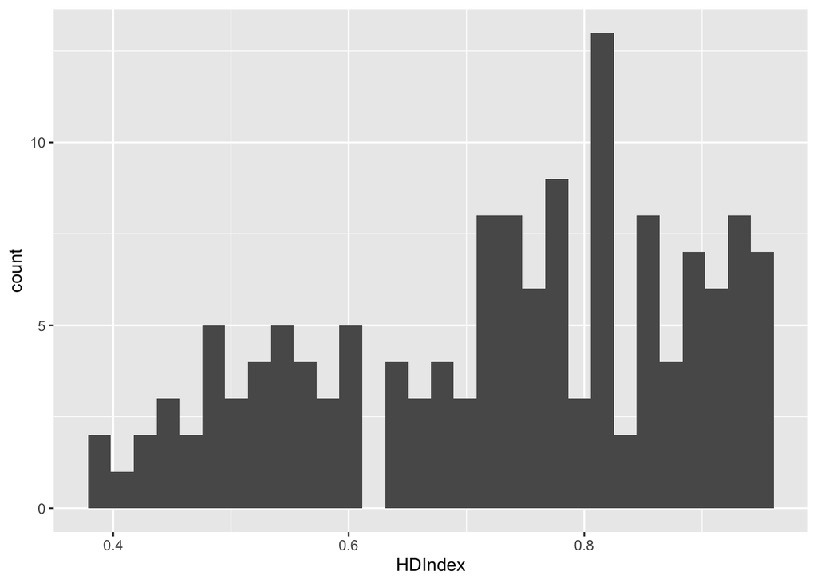

```r
library(ggplot2)
# the base has the data
base=ggplot(data=worldData)

# then you add a particular "geom"
base + geom_histogram(aes(x=HDIndex)) #x for histogram
```

a different **geom**:

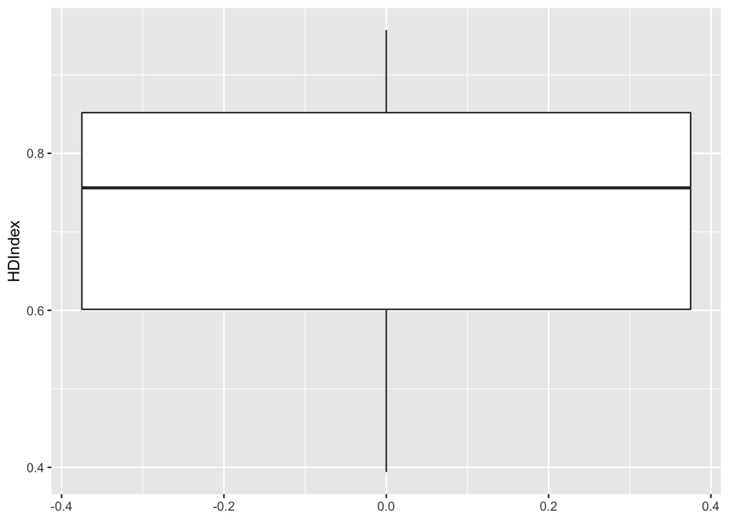

```r
base + geom_boxplot(aes(y=HDIndex))#y for boxplot
```

Let me plot Regime type, a categorical variable:

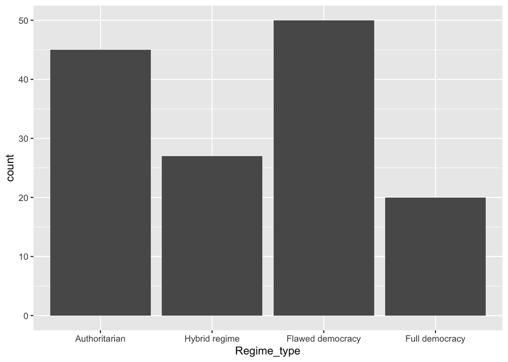

```r
base + geom_bar(aes(x=Regime_type))
```

Let me see the association between regime type and HDIndex:

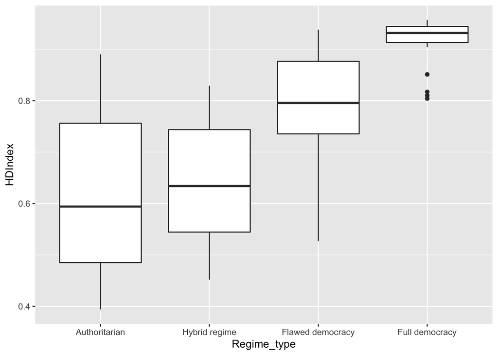

```r
base + geom_boxplot(aes(x=Regime_type,
                        y=HDIndex))
```

Let me see the correlation between democracy index and Human Development Index:

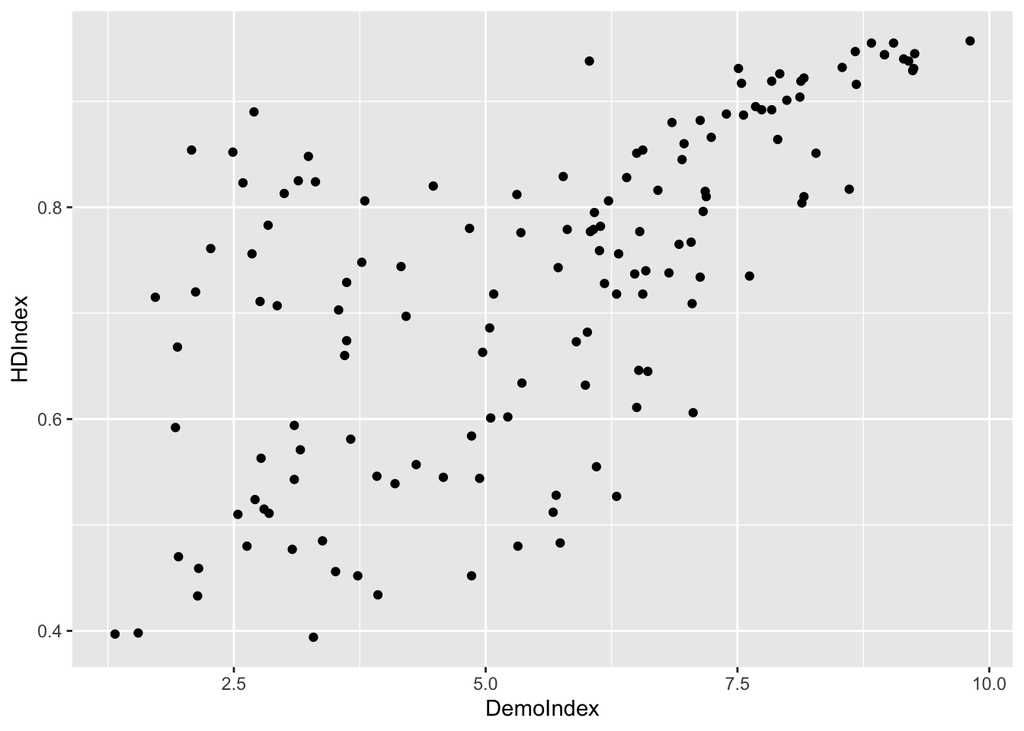

```r
base + geom_point(aes(x=DemoIndex,
                      y=HDIndex))
```

Let me see the correlations among the main three variables we have. For that you need the coefficients and the p_values,and the installation and use of **ggcorrplot**.

```r
library(ggcorrplot)
#all correlations:
indexes=c("HDIndex","DemoIndex","DefenseIndex")
allCorr = cor(worldData[,indexes],
              use = 'pairwise.complete.obs')
#all p_values
allPvals=cor_pmat(worldData[,indexes],
                  use = 'pairwise.complete.obs')
```

Once you have those values, use them here:

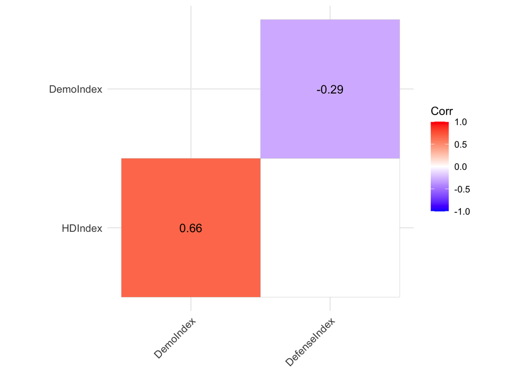

```r
ggcorrplot(allCorr,
           p.mat = allPvals,
           type = "lower",
           lab = TRUE,
           insig = "blank",
           tl.cex = 10)
```

The correlation between HDIndex and Military expenses, while showing Democracy Index regime type:

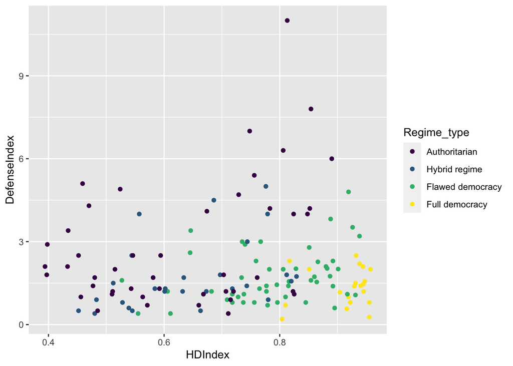

```r
# save result
scat= base + geom_point(aes(HDIndex,
                        DefenseIndex,
            color=Regime_type))
# show result
scat
```

Let me **focus** on some countries:

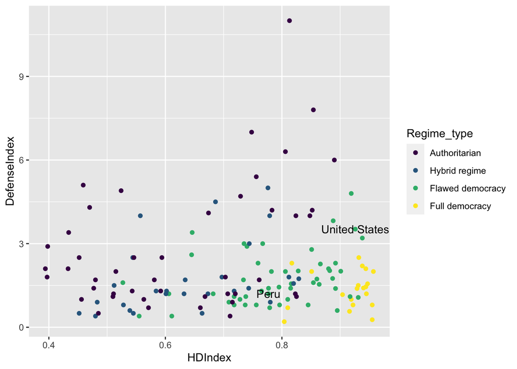

```r
#what countries:
some=c('Peru','United States')

# condition: if contry in some keep the name,
#            otherwise turn the name into ''.
condition=ifelse(worldData$Country %in% some,
                 worldData$Country,
                 '')

# on top of "scat":
scat + geom_text(x=worldData$HDIndex,
                 y=worldData$DefenseIndex,
                 aes(label=condition))
```

The *geom_text* requires more work, which can be eased with the help of **ggrepel**:

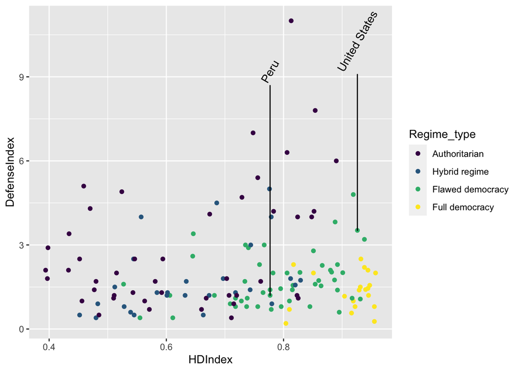

```r
library(ggrepel)

scat + geom_text_repel(x=worldData$HDIndex,
                       y=worldData$DefenseIndex,
                       aes(label=condition),
                       angle=60,
                       nudge_y = 8)
```

## A Clustering example

Let’s find an alternative “regime type” using an advanced technique.

### Part 1: Preparing data

**a.** Subset the data frame:

```r
dfClus=worldData[,c(3,9,13)] #columns for clustering
head(dfClus)
```

```
##   DemoIndex DefenseIndex HDIndex
## 1      9.81         2.00   0.957
## 2      9.26         1.20   0.945
## 3      9.25         1.50   0.931
## 4      9.24         1.39   0.929
## 5      9.20         2.20   0.938
## 6      9.15         1.41   0.940
```

**b.** Rename the rows:

When country is row name, it is not part of the data:

```r
#to
row.names(dfClus)=worldData$Country
head(dfClus)
```

```
##             DemoIndex DefenseIndex HDIndex
## Norway           9.81         2.00   0.957
## Sweden           9.26         1.20   0.945
## New Zealand      9.25         1.50   0.931
## Canada           9.24         1.39   0.929
## Finland          9.20         2.20   0.938
## Denmark          9.15         1.41   0.940
```

**c.** Keep only complete data:

```r
dfClus=dfClus[complete.cases(dfClus),]
```

**d.** Compute distance matrix:

```r
library(cluster)
dfClus_D=cluster::daisy(x=dfClus,metric = 'gower')
```

### Part 2: Clustering process

#### 1. Apply function: you need to indicate the amount of clusters required.

```r
set.seed(123) # for replicability
numberOfClusters=4

res.pam = pam(x=dfClus_D,
              k = numberOfClusters,
              cluster.only = F)
```

#### 2. Save clustering results.

```r
worldData$pam=res.pam$clustering
```

#### 3. Verify cluster ordering.

```r
aggregate(data=worldData[,c(3,9,13,15)],
          .~pam,
          median)
```

```
##   pam DemoIndex DefenseIndex HDIndex
## 1   1     8.125        1.645  0.9190
## 2   2     6.480        1.300  0.7650
## 3   3     3.380        1.300  0.5390
## 4   4     3.190        4.350  0.7945
```

Assign the right label (not always easy):

```r
worldData$pam= factor(worldData$pam,
       level=c(4,3,2,1), #ascending
       label=c(1,2,3,4), #labels
       ordered = T)
```

We could compare:

```r
table(worldData$Regime_type,worldData$pam)
```

```
##
##                     1  2  3  4
##   Authoritarian    15 30  0  0
##   Hybrid regime     3 13 11  0
##   Flawed democracy  0  2 32 16
##   Full democracy    0  0  2 18
```

As you see, the clusters in which countries are do not match exactly in the regime type model.

Let me plot the clusters in a scatter plot:

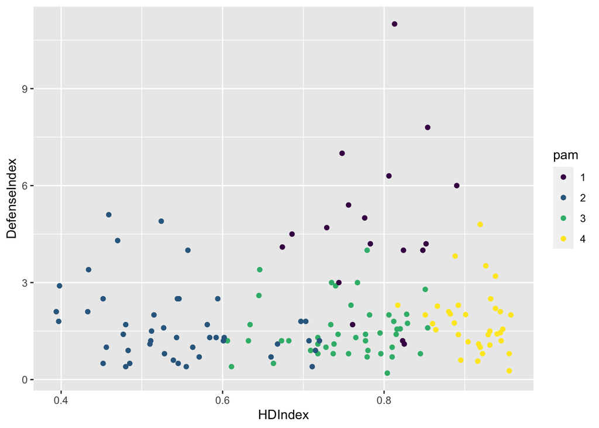

```r
base=ggplot(data=worldData)
scat=base + geom_point(aes(x=HDIndex,
                           y=DefenseIndex,
                           color=pam))
scat
```

### Part 3. Detect poor results.

The object **res.pam** is saving some important info. One of them is the **silhouette widths**. You know a case has not been well clustered if this value is negative.

```r
# get the silhouettes widths:
eval=as.data.frame(res.pam$silinfo$widths)

# get countries poorly clustered
badPAM=eval[eval$sil_width<0,]


#these are the bad clustered countries:
badPAM
```

```
##                  cluster neighbor   sil_width
## Mauritius              2        1 -0.06937949
## Costa Rica             2        1 -0.11794675
## Lesotho                3        2 -0.01453020
## Papua New Guinea       3        2 -0.05409538
## Kyrgyzstan             3        2 -0.11801805
```

Let me keep only the names:

```r
# names of countries are in the row names:
badPAMNames=row.names(badPAM)
```

Let me show these in a scatter plot:

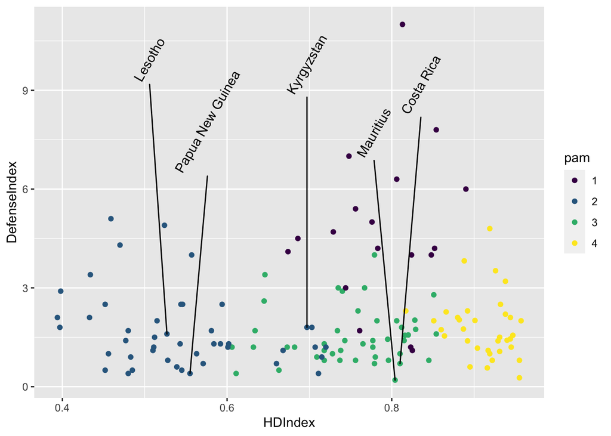

```r
condition=ifelse(worldData$Country %in% badPAMNames,
                 worldData$Country,
                 '')

scat + geom_text_repel(x=worldData$HDIndex,
                       y=worldData$DefenseIndex,
                       label=condition,
                       angle=60,
                       nudge_y = 8)
```

We should see how the world looks like based on democracy clusters. Let’s upload a map:

```r
library(sf)
```

```r
mapWorld=read_sf("mymap.geojson")
```

The plan is to color the countries according to the cluster they belong.

```r
# see data in map
head(mapWorld)
```

```
## Simple feature collection with 6 features and 11 fields
## geometry type:  MULTIPOLYGON
## dimension:      XY
## bbox:           xmin: -61.88722 ymin: -18.01639 xmax: 50.37499 ymax: 42.61805
## geographic CRS: WGS 84
## # A tibble: 6 x 12
##   FIPS  ISO2  ISO3     UN NAME        AREA POP2005 REGION SUBREGION    LON   LAT
##   <chr> <chr> <chr> <int> <chr>      <int>   <int>  <int>     <int>  <dbl> <dbl>
## 1 AC    AG    ATG      28 Antigua …     44  8.30e4     19        29 -61.8   17.1
## 2 AG    DZ    DZA      12 Algeria   238174  3.29e7      2        15   2.63  28.2
## 3 AJ    AZ    AZE      31 Azerbaij…   8260  8.35e6    142       145  47.4   40.4
## 4 AL    AL    ALB       8 Albania     2740  3.15e6    150        39  20.1   41.1
## 5 AM    AM    ARM      51 Armenia     2820  3.02e6    142       145  44.6   40.5
## 6 AO    AO    AGO      24 Angola    124670  1.61e7      2        17  17.5  -12.3
## # … with 1 more variable: geometry <MULTIPOLYGON [°]>
```

Let’s merge our data into the map:

```r
mapWorldVars=merge(mapWorld, #map first
                   worldData,
                   by='ISO3')
```

Let’s do the map step by step:

1. Plot the map (basemap):

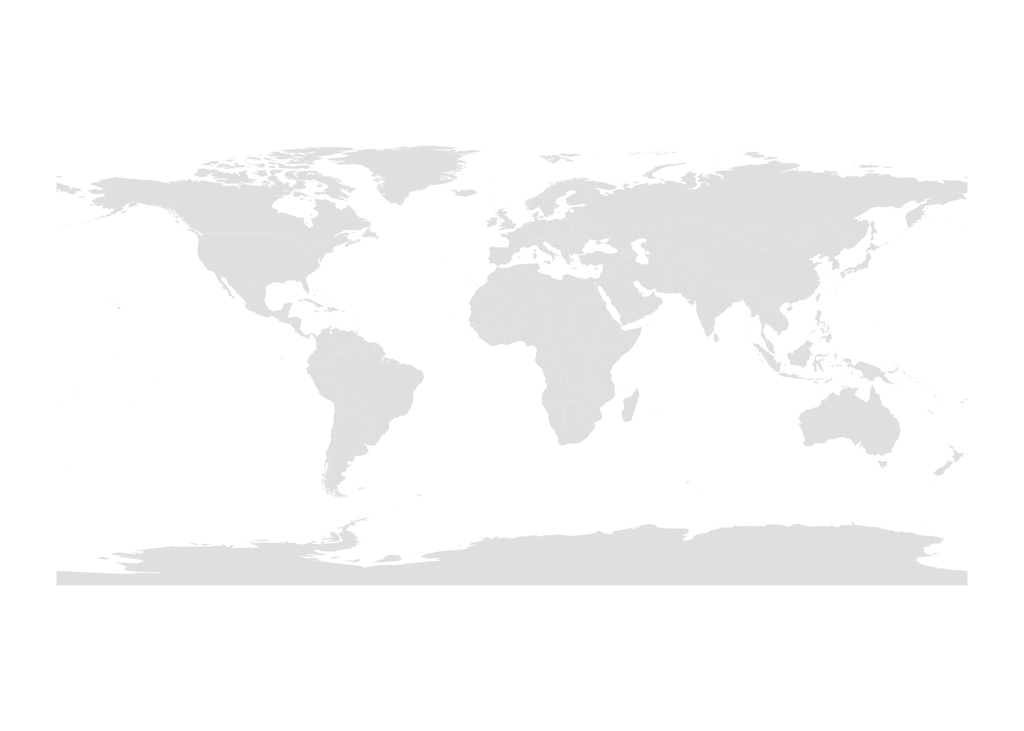

```r
library(ggplot2)
# plot original map
base=ggplot(data=mapWorld) + geom_sf(fill='grey90',
                                     color=NA) + theme_classic()

base #base map
```

Now paint the countries (ggplot decides color):

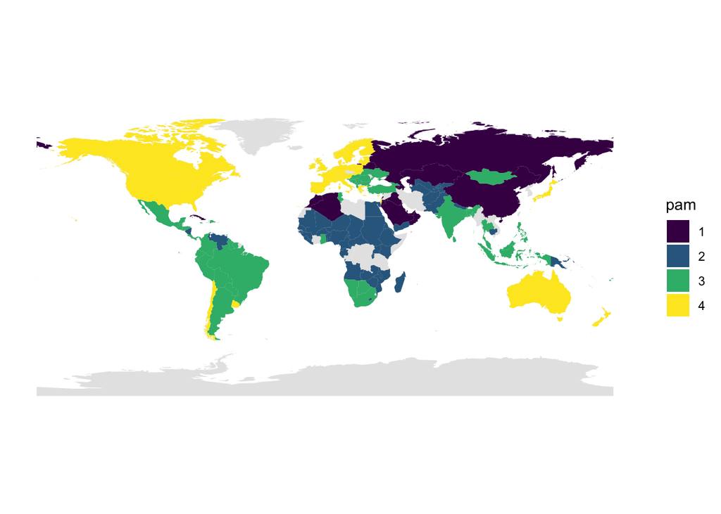

```r
clusterMap= base + geom_sf(data=mapWorldVars,
                           aes(fill=pam),
                           color=NA) # color of border
clusterMap
```

Now you choose the palette (get it from [here](http://colorbrewer2.org/)):

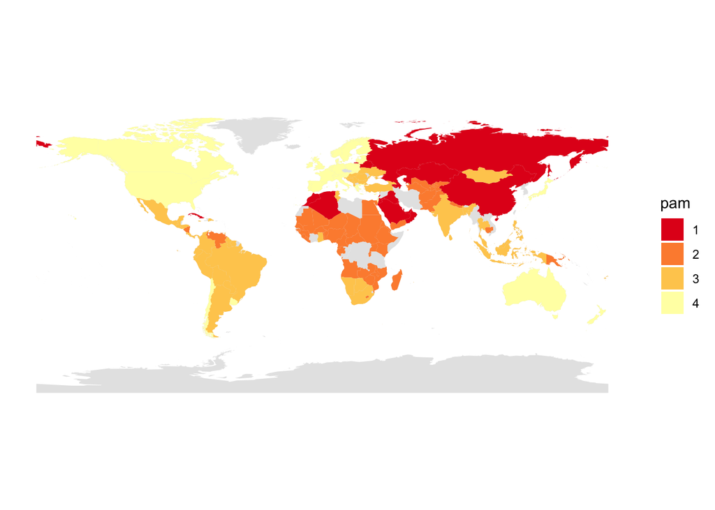

```r
clusterMap+ scale_fill_brewer(palette ='YlOrRd',
                              direction = -1)
```

Some more customization:

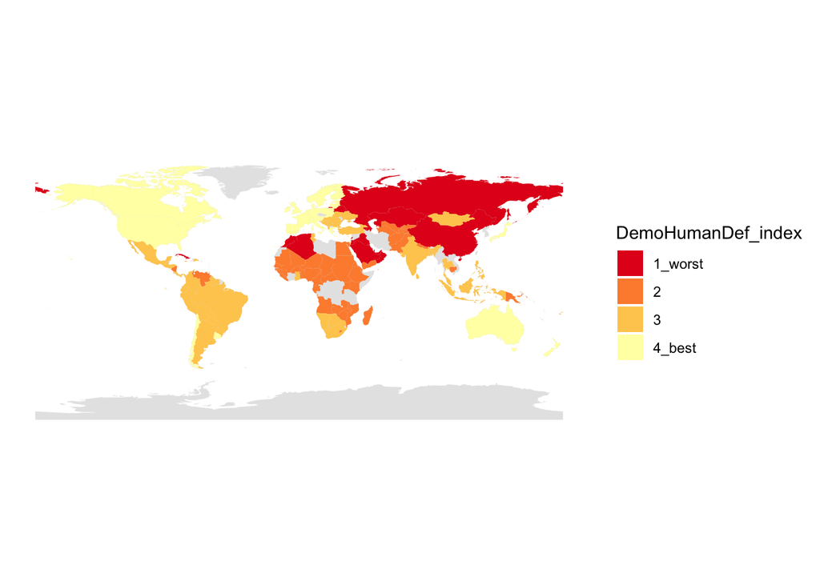

```r
#previously
theLegLabels=c('1_worst',2,3,'4_best')
theLegTitle="DemoHumanDef_index"

#now
clusterMap+ scale_fill_brewer(palette ='YlOrRd',
                              direction = -1,                               labels=theLegLabels,
                              name=theLegTitle)
```

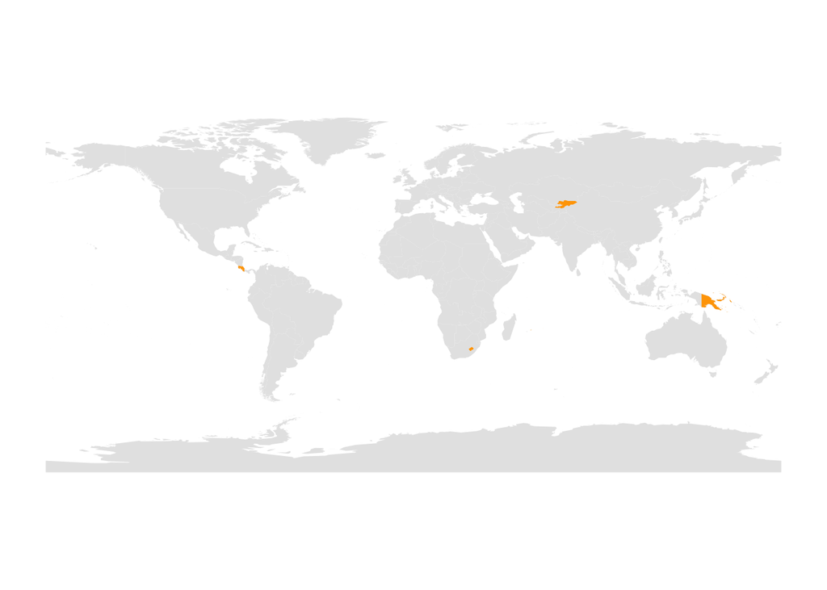

```r
BadData=mapWorldVars[mapWorldVars$Country%in%badPAMNames,]
clusterMapBad= base + geom_sf(data=BadData,
                           fill='orange',
                           color=NA) # color of border
clusterMapBad
```

home ________

# FACTOR ANALYSIS

Simply speaking, this technique tries to express in one (or few) dimension(s) the behavior of several others. FA assumes that the several input variables have ‘something’ in common, there is something **latent** that the set of input variables represent.

Let me subset our original data frame:

```r
#current names
names(worldData)
```

```
##  [1] "Country"                         "Regime_type"
##  [3] "DemoIndex"                       "Electoral_process_and_pluralism"
##  [5] "Functioning_of_government"       "Political_participation"
##  [7] "Political_culture"               "Civil_liberties"
##  [9] "DefenseIndex"                    "FIPS"
## [11] "ISO2"                            "ISO3"
## [13] "HDIndex"                         "HDIndexdico"
## [15] "pam"
```

```r
selection=c("Country","Electoral_process_and_pluralism","Functioning_of_government","Political_participation","Political_culture","Civil_liberties")

dataForFA=worldData[,selection]
```

Our *dataForFA* data frame has the data to compute the one index we need. I will show the technique called **confirmatory factor analysis**:

```r
library(lavaan)
model='
democracy=~Electoral_process_and_pluralism + Functioning_of_government + Political_participation + Political_culture + Civil_liberties
'

fit<-cfa(model, data = dataForFA,std.lv=TRUE)
democracy_CFA=lavPredict(fit)
```

The index computed is not in a range from 0 to 10:

```r
democracy_CFA[1:10]
```

```
##  [1] 1.611995 1.436805 1.583011 1.499622 1.510723 1.432315 1.527511 1.523715
##  [9] 1.337903 1.298159
```

We force its return to “0 to 10”:

```r
library(scales)
democracy_CFA_Norm=rescale(as.vector(democracy_CFA),
                     to = c(0, 10))
democracy_CFA_Norm[1:10]
```

```
##  [1] 10.000000  9.500700  9.917393  9.679731  9.711369  9.487904  9.759215
##  [8]  9.748399  9.218827  9.105556
```

So, this is our index:

```r
worldData$demo_CFA=democracy_CFA_Norm
```

Let me compare the new index with the original score:

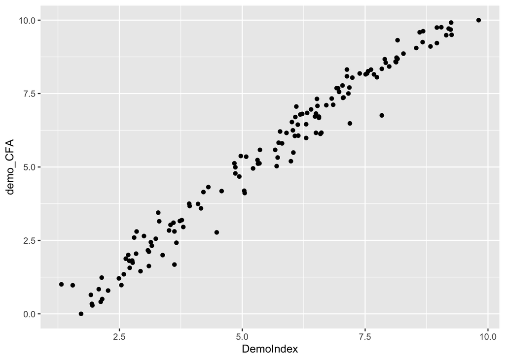

```r
base=ggplot(data=worldData,
            aes(x=DemoIndex,y=demo_CFA))
base+geom_point()
```

Let me see some evaluation measures of our index for democracy:

```r
eval_democracy=parameterEstimates(fit,
                                  standardized =TRUE)
```

- Loadings

```r
eval_democracy[eval_democracy$op=="=~",c('rhs','std.all','pvalue')]
```

```
##                               rhs std.all pvalue
## 1 Electoral_process_and_pluralism   0.927      0
## 2       Functioning_of_government   0.862      0
## 3         Political_participation   0.803      0
## 4               Political_culture   0.652      0
## 5                 Civil_liberties   0.974      0
```

- Some coefficients:

```r
coeffs_democracy=as.list(fitMeasures(fit))
```

- You want p.value of Chi-Square greater than 0.05:

```r
coeffs_democracy[c("chisq", "df", "pvalue")]
```

```
## $chisq
## [1] 48.94943
##
## $df
## [1] 5
##
## $pvalue
## [1] 2.272699e-09
```

- You want the Tucker-Lewis > 0.9:

```r
coeffs_democracy$tli # > 0.90
```

```
## [1] 0.8690783
```

- You want RMSEA < 0.05:

```r
coeffs_democracy[c( 'rmsea.ci.lower','rmsea','rmsea.ci.upper')]
```

```
## $rmsea.ci.lower
## [1] 0.1881764
##
## $rmsea
## [1] 0.2487983
##
## $rmsea.ci.upper
## [1] 0.3144803
```

You can see how it looks:

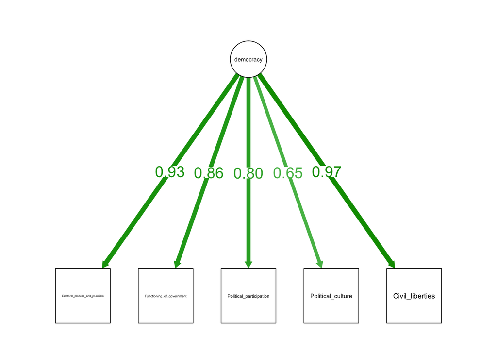

```r
library(semPlot)
semPaths(fit, what='std', nCharNodes=0, sizeMan=12,
         edge.label.cex=1.5, fade=T,residuals = F)
```

## Regression

These may be the easiest functions:

```r
# hypothesis 1:

# The more countries expend in armed forces
# the better HDIndex:

hypo1=formula(HDIndex~DefenseIndex)
regre1=lm(hypo1,data = worldData)
```

See the result:

```r
summary(regre1)
```

```
##
## Call:
## lm(formula = hypo1, data = worldData)
##
## Residuals:
##      Min       1Q   Median       3Q      Max
## -0.33704 -0.12130  0.01838  0.12119  0.23957
##
## Coefficients:
##              Estimate Std. Error t value Pr(>|t|)
## (Intercept)  0.713422   0.021115   33.79   <2e-16 ***
## DefenseIndex 0.007456   0.008104    0.92    0.359
## ---
## Signif. codes:  0 '***' 0.001 '**' 0.01 '*' 0.05 '.' 0.1 ' ' 1
##
## Residual standard error: 0.1557 on 140 degrees of freedom
## Multiple R-squared:  0.006009,   Adjusted R-squared:  -0.001091
## F-statistic: 0.8464 on 1 and 140 DF,  p-value: 0.3592
```

You can plot that:

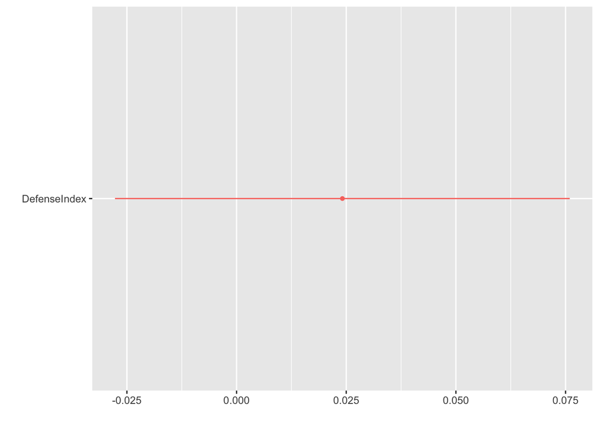

```r
library(dotwhisker)

dwplot(regre1)
```

Let’s try another hypothesis:

```r
# hypothesis 2:

# The more countries expend in armed forces and the more democratic, the better HDIndex
hypo2=formula(HDIndex~DefenseIndex  + DemoIndex)
regre2=lm(hypo2,data = worldData)
```

Result:

```r
summary(regre2)
```

```
##
## Call:
## lm(formula = hypo2, data = worldData)
##
## Residuals:
##      Min       1Q   Median       3Q      Max
## -0.24824 -0.07507  0.01380  0.06495  0.27385
##
## Coefficients:
##              Estimate Std. Error t value Pr(>|t|)
## (Intercept)  0.378256   0.031763  11.909  < 2e-16 ***
## DefenseIndex 0.028290   0.005974   4.736 5.32e-06 ***
## DemoIndex    0.052874   0.004426  11.945  < 2e-16 ***
## ---
## Signif. codes:  0 '***' 0.001 '**' 0.01 '*' 0.05 '.' 0.1 ' ' 1
##
## Residual standard error: 0.1097 on 139 degrees of freedom
## Multiple R-squared:  0.5095, Adjusted R-squared:  0.5024
## F-statistic: 72.19 on 2 and 139 DF,  p-value: < 2.2e-16
```

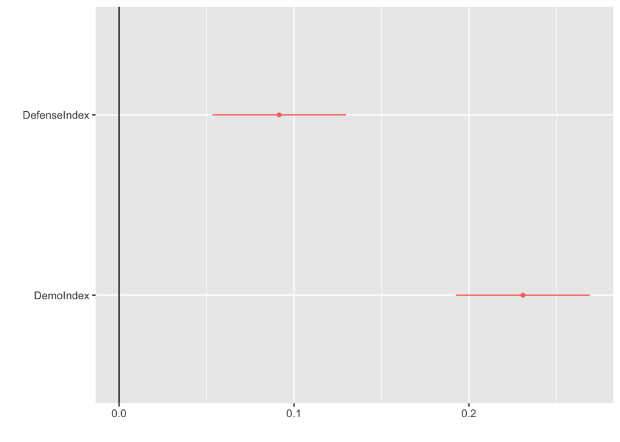

```r
dwplot(regre2) + geom_vline(xintercept = 0)
```

Which one should I choose?

```r
anova(regre1,regre2)
```

```
## Analysis of Variance Table
##
## Model 1: HDIndex ~ DefenseIndex
## Model 2: HDIndex ~ DefenseIndex + DemoIndex
##   Res.Df    RSS Df Sum of Sq      F    Pr(>F)
## 1    140 3.3922
## 2    139 1.6739  1    1.7183 142.68 < 2.2e-16 ***
## ---
## Signif. codes:  0 '***' 0.001 '**' 0.01 '*' 0.05 '.' 0.1 ' ' 1
```

## Exercise

REDO all this code using the file **allmerged_new.rds**, and take note of the differences.

home